# Risk Factor Analysis

## Outcome Variable

**Outcome Variable:** stunted

## Predictor Variables

**Intervention Variable:** sex

**Adjustment Set:**

unadjusted

## Stratifying Variables

The analysis was stratified on these variable(s):

- agecat
- studyid
- country

## Data Summary

| agecat | studyid | country | sex | stunted | n_cell | n | outcome_variable |
| --- | --- | --- | --- | --- | --- | --- | --- |
| Birth | ki0047075b-MAL-ED | BANGLADESH | Female | 0 | 94 | 231 | stunted |
| Birth | ki0047075b-MAL-ED | BANGLADESH | Female | 1 | 24 | 231 | stunted |
| Birth | ki0047075b-MAL-ED | BANGLADESH | Male | 0 | 93 | 231 | stunted |
| Birth | ki0047075b-MAL-ED | BANGLADESH | Male | 1 | 20 | 231 | stunted |
| Birth | ki0047075b-MAL-ED | BRAZIL | Female | 0 | 28 | 65 | stunted |
| Birth | ki0047075b-MAL-ED | BRAZIL | Female | 1 | 6 | 65 | stunted |
| Birth | ki0047075b-MAL-ED | BRAZIL | Male | 0 | 28 | 65 | stunted |
| Birth | ki0047075b-MAL-ED | BRAZIL | Male | 1 | 3 | 65 | stunted |
| Birth | ki0047075b-MAL-ED | INDIA | Female | 0 | 20 | 47 | stunted |
| Birth | ki0047075b-MAL-ED | INDIA | Female | 1 | 3 | 47 | stunted |
| Birth | ki0047075b-MAL-ED | INDIA | Male | 0 | 17 | 47 | stunted |
| Birth | ki0047075b-MAL-ED | INDIA | Male | 1 | 7 | 47 | stunted |
| Birth | ki0047075b-MAL-ED | NEPAL | Female | 0 | 15 | 27 | stunted |
| Birth | ki0047075b-MAL-ED | NEPAL | Female | 1 | 2 | 27 | stunted |
| Birth | ki0047075b-MAL-ED | NEPAL | Male | 0 | 10 | 27 | stunted |
| Birth | ki0047075b-MAL-ED | NEPAL | Male | 1 | 0 | 27 | stunted |
| Birth | ki0047075b-MAL-ED | PERU | Female | 0 | 105 | 233 | stunted |
| Birth | ki0047075b-MAL-ED | PERU | Female | 1 | 11 | 233 | stunted |
| Birth | ki0047075b-MAL-ED | PERU | Male | 0 | 102 | 233 | stunted |
| Birth | ki0047075b-MAL-ED | PERU | Male | 1 | 15 | 233 | stunted |
| Birth | ki0047075b-MAL-ED | SOUTH AFRICA | Female | 0 | 54 | 123 | stunted |
| Birth | ki0047075b-MAL-ED | SOUTH AFRICA | Female | 1 | 4 | 123 | stunted |
| Birth | ki0047075b-MAL-ED | SOUTH AFRICA | Male | 0 | 59 | 123 | stunted |
| Birth | ki0047075b-MAL-ED | SOUTH AFRICA | Male | 1 | 6 | 123 | stunted |
| Birth | ki0047075b-MAL-ED | TANZANIA, UNITED REPUBLIC OF | Female | 0 | 53 | 125 | stunted |
| Birth | ki0047075b-MAL-ED | TANZANIA, UNITED REPUBLIC OF | Female | 1 | 17 | 125 | stunted |
| Birth | ki0047075b-MAL-ED | TANZANIA, UNITED REPUBLIC OF | Male | 0 | 49 | 125 | stunted |
| Birth | ki0047075b-MAL-ED | TANZANIA, UNITED REPUBLIC OF | Male | 1 | 6 | 125 | stunted |
| Birth | ki1000108-CMC-V-BCS-2002 | INDIA | Female | 0 | 41 | 92 | stunted |
| Birth | ki1000108-CMC-V-BCS-2002 | INDIA | Female | 1 | 5 | 92 | stunted |

[output cut: 298 more lines]

The following strata were considered:

- agecat: 24 months, studyid: ki0047075b-MAL-ED, country: BANGLADESH
- agecat: 24 months, studyid: ki0047075b-MAL-ED, country: BRAZIL
- agecat: 24 months, studyid: ki0047075b-MAL-ED, country: INDIA
- agecat: 24 months, studyid: ki0047075b-MAL-ED, country: NEPAL
- agecat: 24 months, studyid: ki0047075b-MAL-ED, country: PERU
- agecat: 24 months, studyid: ki0047075b-MAL-ED, country: SOUTH AFRICA
- agecat: 24 months, studyid: ki0047075b-MAL-ED, country: TANZANIA, UNITED REPUBLIC OF
- agecat: 24 months, studyid: ki1000108-CMC-V-BCS-2002, country: INDIA
- agecat: 24 months, studyid: ki1000108-IRC, country: INDIA
- agecat: 24 months, studyid: ki1000109-EE, country: PAKISTAN
- agecat: 24 months, studyid: ki1017093-NIH-Birth, country: BANGLADESH
- agecat: 24 months, studyid: ki1017093b-PROVIDE, country: BANGLADESH
- agecat: 24 months, studyid: ki1017093c-NIH-Crypto, country: BANGLADESH
- agecat: 24 months, studyid: ki1066203-TanzaniaChild2, country: TANZANIA, UNITED REPUBLIC OF
- agecat: 24 months, studyid: ki1101329-Keneba, country: GAMBIA
- agecat: 24 months, studyid: ki1113344-GMS-Nepal, country: NEPAL
- agecat: 24 months, studyid: ki1114097-CMIN, country: BANGLADESH
- agecat: 24 months, studyid: ki1114097-CONTENT, country: PERU
- agecat: 24 months, studyid: ki1119695-PROBIT, country: BELARUS
- agecat: 24 months, studyid: ki1126311-ZVITAMBO, country: ZIMBABWE
- agecat: 24 months, studyid: ki1135781-COHORTS, country: GUATEMALA
- agecat: 24 months, studyid: ki1135781-COHORTS, country: INDIA
- agecat: 24 months, studyid: ki1135781-COHORTS, country: PHILIPPINES
- agecat: 24 months, studyid: ki1148112-LCNI-5, country: MALAWI
- agecat: 24 months, studyid: kiGH5241-JiVitA-3, country: BANGLADESH
- agecat: 24 months, studyid: kiGH5241-JiVitA-4, country: BANGLADESH
- agecat: 6 months, studyid: ki0047075b-MAL-ED, country: BANGLADESH
- agecat: 6 months, studyid: ki0047075b-MAL-ED, country: BRAZIL
- agecat: 6 months, studyid: ki0047075b-MAL-ED, country: INDIA
- agecat: 6 months, studyid: ki0047075b-MAL-ED, country: NEPAL
- agecat: 6 months, studyid: ki0047075b-MAL-ED, country: PERU
- agecat: 6 months, studyid: ki0047075b-MAL-ED, country: SOUTH AFRICA
- agecat: 6 months, studyid: ki0047075b-MAL-ED, country: TANZANIA, UNITED REPUBLIC OF
- agecat: 6 months, studyid: ki1000108-CMC-V-BCS-2002, country: INDIA
- agecat: 6 months, studyid: ki1000108-IRC, country: INDIA
- agecat: 6 months, studyid: ki1000109-EE, country: PAKISTAN
- agecat: 6 months, studyid: ki1000109-ResPak, country: PAKISTAN
- agecat: 6 months, studyid: ki1000304b-SAS-CompFeed, country: INDIA
- agecat: 6 months, studyid: ki1000304b-SAS-FoodSuppl, country: INDIA
- agecat: 6 months, studyid: ki1017093-NIH-Birth, country: BANGLADESH
- agecat: 6 months, studyid: ki1017093b-PROVIDE, country: BANGLADESH
- agecat: 6 months, studyid: ki1017093c-NIH-Crypto, country: BANGLADESH
- agecat: 6 months, studyid: ki1066203-TanzaniaChild2, country: TANZANIA, UNITED REPUBLIC OF
- agecat: 6 months, studyid: ki1101329-Keneba, country: GAMBIA
- agecat: 6 months, studyid: ki1112895-Guatemala BSC, country: GUATEMALA
- agecat: 6 months, studyid: ki1113344-GMS-Nepal, country: NEPAL
- agecat: 6 months, studyid: ki1114097-CMIN, country: BANGLADESH
- agecat: 6 months, studyid: ki1114097-CONTENT, country: PERU
- agecat: 6 months, studyid: ki1119695-PROBIT, country: BELARUS
- agecat: 6 months, studyid: ki1126311-ZVITAMBO, country: ZIMBABWE
- agecat: 6 months, studyid: ki1135781-COHORTS, country: GUATEMALA
- agecat: 6 months, studyid: ki1135781-COHORTS, country: INDIA
- agecat: 6 months, studyid: ki1135781-COHORTS, country: PHILIPPINES
- agecat: 6 months, studyid: ki1148112-LCNI-5, country: MALAWI
- agecat: 6 months, studyid: kiGH5241-JiVitA-3, country: BANGLADESH
- agecat: 6 months, studyid: kiGH5241-JiVitA-4, country: BANGLADESH
- agecat: Birth, studyid: ki0047075b-MAL-ED, country: BANGLADESH
- agecat: Birth, studyid: ki0047075b-MAL-ED, country: BRAZIL
- agecat: Birth, studyid: ki0047075b-MAL-ED, country: INDIA
- agecat: Birth, studyid: ki0047075b-MAL-ED, country: NEPAL
- agecat: Birth, studyid: ki0047075b-MAL-ED, country: PERU
- agecat: Birth, studyid: ki0047075b-MAL-ED, country: SOUTH AFRICA
- agecat: Birth, studyid: ki0047075b-MAL-ED, country: TANZANIA, UNITED REPUBLIC OF
- agecat: Birth, studyid: ki1000108-CMC-V-BCS-2002, country: INDIA
- agecat: Birth, studyid: ki1000108-IRC, country: INDIA
- agecat: Birth, studyid: ki1000109-EE, country: PAKISTAN
- agecat: Birth, studyid: ki1000109-ResPak, country: PAKISTAN
- agecat: Birth, studyid: ki1000304b-SAS-CompFeed, country: INDIA
- agecat: Birth, studyid: ki1017093-NIH-Birth, country: BANGLADESH
- agecat: Birth, studyid: ki1017093b-PROVIDE, country: BANGLADESH
- agecat: Birth, studyid: ki1017093c-NIH-Crypto, country: BANGLADESH
- agecat: Birth, studyid: ki1101329-Keneba, country: GAMBIA
- agecat: Birth, studyid: ki1113344-GMS-Nepal, country: NEPAL
- agecat: Birth, studyid: ki1114097-CMIN, country: BANGLADESH
- agecat: Birth, studyid: ki1114097-CONTENT, country: PERU
- agecat: Birth, studyid: ki1119695-PROBIT, country: BELARUS
- agecat: Birth, studyid: ki1126311-ZVITAMBO, country: ZIMBABWE
- agecat: Birth, studyid: ki1135781-COHORTS, country: GUATEMALA
- agecat: Birth, studyid: ki1135781-COHORTS, country: INDIA
- agecat: Birth, studyid: ki1135781-COHORTS, country: PHILIPPINES
- agecat: Birth, studyid: kiGH5241-JiVitA-3, country: BANGLADESH
- agecat: Birth, studyid: kiGH5241-JiVitA-4, country: BANGLADESH

### Dropped Strata

Some strata were dropped due to rare outcomes:

- agecat: Birth, studyid: ki0047075b-MAL-ED, country: BRAZIL
- agecat: Birth, studyid: ki0047075b-MAL-ED, country: INDIA
- agecat: Birth, studyid: ki0047075b-MAL-ED, country: NEPAL
- agecat: Birth, studyid: ki0047075b-MAL-ED, country: SOUTH AFRICA
- agecat: Birth, studyid: ki1114097-CMIN, country: BANGLADESH
- agecat: Birth, studyid: ki1114097-CONTENT, country: PERU
- agecat: 6 months, studyid: ki0047075b-MAL-ED, country: BRAZIL
- agecat: 6 months, studyid: ki0047075b-MAL-ED, country: NEPAL
- agecat: 6 months, studyid: ki1114097-CONTENT, country: PERU
- agecat: 24 months, studyid: ki0047075b-MAL-ED, country: BRAZIL
- agecat: 24 months, studyid: ki1066203-TanzaniaChild2, country: TANZANIA, UNITED REPUBLIC OF
- agecat: 24 months, studyid: ki1114097-CONTENT, country: PERU

## Methods Detail

We’re interested in the causal parameters $E[Y_a]$ for all values of $a \in \mathcal{A}$. These parameters represent the mean outcome if, possibly contrary to fact, we intervened to set all units to have $A=a$. Under the randomization and positivity assumptions, these are identified by the statistical parameters $\psi_a=E_W[E_{Y|A,W}(Y|A=a,W)]$. In addition, we’re interested in the mean of $Y$, $E[Y]$ under no intervention (the observed mean). We will estimate these parameters by using SuperLearner to fit the relevant likelihood factors – $E_{Y|A,W}(Y|A=a,W)$ and $p(A=a|W)$, and then updating our likelihood fit using a joint TMLE.

For unadjusted analyses ($W=\{\}$), initial likelihoods were estimated using Lrnr_glm to estimate the simple $E(Y|A)$ and Lrnr_mean to estimate $p(A)$. For adjusted analyses, a small library containing Lrnr_glmnet, Lrnr_xgboost, and Lrnr_mean was used.

Having estimated these parameters, we will then use the delta method to estimate relative risks and attributable risks relative to a prespecified baseline level of $A$.

# Results Detail

## Results Plots

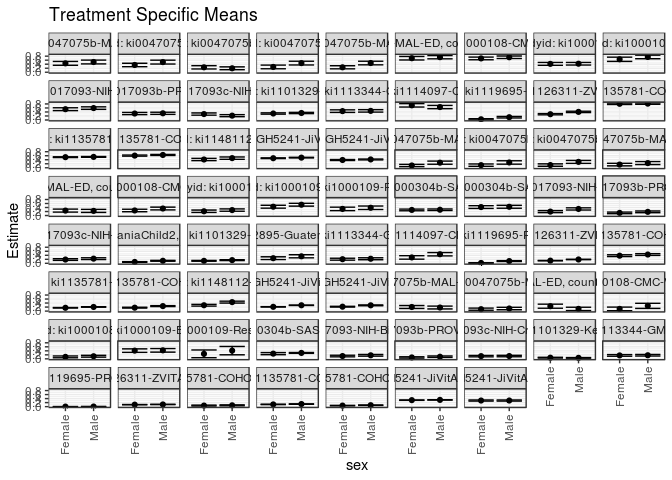

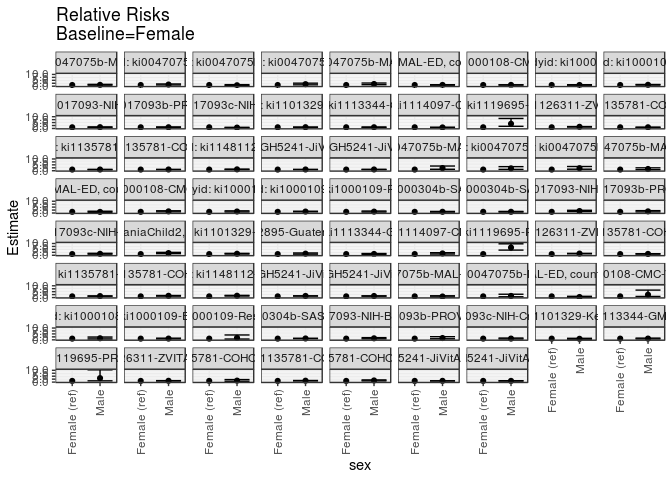

[figure not shown]

[figure not shown]

## Results Table

### Parameter: TSM

| agecat | studyid | country | intervention_level | baseline_level | estimate | ci_lower | ci_upper |
| --- | --- | --- | --- | --- | --- | --- | --- |
| Birth | ki0047075b-MAL-ED | BANGLADESH | Female | NA | 0.2033898 | 0.1306057 | 0.2761740 |
| Birth | ki0047075b-MAL-ED | BANGLADESH | Male | NA | 0.1769912 | 0.1064684 | 0.2475139 |
| Birth | ki0047075b-MAL-ED | PERU | Female | NA | 0.0948276 | 0.0413975 | 0.1482577 |
| Birth | ki0047075b-MAL-ED | PERU | Male | NA | 0.1282051 | 0.0674967 | 0.1889136 |
| Birth | ki0047075b-MAL-ED | TANZANIA, UNITED REPUBLIC OF | Female | NA | 0.2428571 | 0.1419998 | 0.3437145 |
| Birth | ki0047075b-MAL-ED | TANZANIA, UNITED REPUBLIC OF | Male | NA | 0.1090909 | 0.0263687 | 0.1918131 |
| Birth | ki1000108-CMC-V-BCS-2002 | INDIA | Female | NA | 0.1086957 | 0.0182555 | 0.1991358 |
| Birth | ki1000108-CMC-V-BCS-2002 | INDIA | Male | NA | 0.2608696 | 0.1332802 | 0.3884590 |
| Birth | ki1000108-IRC | INDIA | Female | NA | 0.0982659 | 0.0538513 | 0.1426805 |
| Birth | ki1000108-IRC | INDIA | Male | NA | 0.1302326 | 0.0851871 | 0.1752780 |
| Birth | ki1000109-EE | PAKISTAN | Female | NA | 0.4098361 | 0.3223848 | 0.4972874 |
| Birth | ki1000109-EE | PAKISTAN | Male | NA | 0.4237288 | 0.3343836 | 0.5130740 |
| Birth | ki1000109-ResPak | PAKISTAN | Female | NA | 0.2500000 | 0.0579269 | 0.4420731 |
| Birth | ki1000109-ResPak | PAKISTAN | Male | NA | 0.4090909 | 0.2011501 | 0.6170317 |
| Birth | ki1000304b-SAS-CompFeed | INDIA | Female | NA | 0.2598291 | 0.2083613 | 0.3112968 |
| Birth | ki1000304b-SAS-CompFeed | INDIA | Male | NA | 0.2953523 | 0.2739619 | 0.3167428 |
| Birth | ki1017093-NIH-Birth | BANGLADESH | Female | NA | 0.1398601 | 0.0996298 | 0.1800905 |
| Birth | ki1017093-NIH-Birth | BANGLADESH | Male | NA | 0.1770186 | 0.1352950 | 0.2187423 |
| Birth | ki1017093b-PROVIDE | BANGLADESH | Female | NA | 0.0703125 | 0.0389640 | 0.1016610 |
| Birth | ki1017093b-PROVIDE | BANGLADESH | Male | NA | 0.1060071 | 0.0701072 | 0.1419069 |
| Birth | ki1017093c-NIH-Crypto | BANGLADESH | Female | NA | 0.1358696 | 0.1008370 | 0.1709021 |
| Birth | ki1017093c-NIH-Crypto | BANGLADESH | Male | NA | 0.1401099 | 0.1044278 | 0.1757920 |
| Birth | ki1101329-Keneba | GAMBIA | Female | NA | 0.0581081 | 0.0412468 | 0.0749694 |
| Birth | ki1101329-Keneba | GAMBIA | Male | NA | 0.0498132 | 0.0347607 | 0.0648657 |
| Birth | ki1113344-GMS-Nepal | NEPAL | Female | NA | 0.1707317 | 0.1299817 | 0.2114817 |
| Birth | ki1113344-GMS-Nepal | NEPAL | Male | NA | 0.1793478 | 0.1401227 | 0.2185729 |
| Birth | ki1119695-PROBIT | BELARUS | Female | NA | 0.0011144 | 0.0002241 | 0.0020046 |
| Birth | ki1119695-PROBIT | BELARUS | Male | NA | 0.0037252 | 0.0011077 | 0.0063427 |
| Birth | ki1126311-ZVITAMBO | ZIMBABWE | Female | NA | 0.0987709 | 0.0916547 | 0.1058871 |
| Birth | ki1126311-ZVITAMBO | ZIMBABWE | Male | NA | 0.1076945 | 0.1004947 | 0.1148942 |

[output cut: 110 more lines]

### Parameter: E(Y)

| agecat | studyid | country | intervention_level | baseline_level | estimate | ci_lower | ci_upper |
| --- | --- | --- | --- | --- | --- | --- | --- |
| Birth | ki0047075b-MAL-ED | BANGLADESH | NA | NA | 0.1904762 | 0.1397281 | 0.2412242 |
| Birth | ki0047075b-MAL-ED | PERU | NA | NA | 0.1115880 | 0.0710726 | 0.1521034 |
| Birth | ki0047075b-MAL-ED | TANZANIA, UNITED REPUBLIC OF | NA | NA | 0.1840000 | 0.1157989 | 0.2522011 |
| Birth | ki1000108-CMC-V-BCS-2002 | INDIA | NA | NA | 0.1847826 | 0.1050392 | 0.2645260 |
| Birth | ki1000108-IRC | INDIA | NA | NA | 0.1159794 | 0.0840777 | 0.1478811 |
| Birth | ki1000109-EE | PAKISTAN | NA | NA | 0.4166667 | 0.3541635 | 0.4791698 |
| Birth | ki1000109-ResPak | PAKISTAN | NA | NA | 0.3333333 | 0.1890388 | 0.4776279 |
| Birth | ki1000304b-SAS-CompFeed | INDIA | NA | NA | 0.2787540 | 0.2475949 | 0.3099131 |
| Birth | ki1017093-NIH-Birth | BANGLADESH | NA | NA | 0.1595395 | 0.1304091 | 0.1886699 |
| Birth | ki1017093b-PROVIDE | BANGLADESH | NA | NA | 0.0890538 | 0.0649864 | 0.1131212 |
| Birth | ki1017093c-NIH-Crypto | BANGLADESH | NA | NA | 0.1379781 | 0.1129774 | 0.1629789 |
| Birth | ki1101329-Keneba | GAMBIA | NA | NA | 0.0537913 | 0.0425309 | 0.0650518 |
| Birth | ki1113344-GMS-Nepal | NEPAL | NA | NA | 0.1752874 | 0.1470202 | 0.2035545 |
| Birth | ki1119695-PROBIT | BELARUS | NA | NA | 0.0023758 | 0.0010936 | 0.0036580 |
| Birth | ki1126311-ZVITAMBO | ZIMBABWE | NA | NA | 0.1033514 | 0.0982859 | 0.1084168 |
| Birth | ki1135781-COHORTS | GUATEMALA | NA | NA | 0.0586854 | 0.0428942 | 0.0744767 |
| Birth | ki1135781-COHORTS | INDIA | NA | NA | 0.1192771 | 0.1114807 | 0.1270735 |
| Birth | ki1135781-COHORTS | PHILIPPINES | NA | NA | 0.0613115 | 0.0527962 | 0.0698268 |
| Birth | kiGH5241-JiVitA-3 | BANGLADESH | NA | NA | 0.3289690 | 0.3216017 | 0.3363364 |
| Birth | kiGH5241-JiVitA-4 | BANGLADESH | NA | NA | 0.3035778 | 0.2836422 | 0.3235133 |
| 6 months | ki0047075b-MAL-ED | BANGLADESH | NA | NA | 0.1825726 | 0.1336978 | 0.2314474 |
| 6 months | ki0047075b-MAL-ED | INDIA | NA | NA | 0.1906780 | 0.1404524 | 0.2409036 |
| 6 months | ki0047075b-MAL-ED | PERU | NA | NA | 0.2197802 | 0.1705687 | 0.2689917 |
| 6 months | ki0047075b-MAL-ED | SOUTH AFRICA | NA | NA | 0.1968504 | 0.1478551 | 0.2458457 |
| 6 months | ki0047075b-MAL-ED | TANZANIA, UNITED REPUBLIC OF | NA | NA | 0.2388664 | 0.1855834 | 0.2921494 |
| 6 months | ki1000108-CMC-V-BCS-2002 | INDIA | NA | NA | 0.3008130 | 0.2539566 | 0.3476694 |
| 6 months | ki1000108-IRC | INDIA | NA | NA | 0.2457002 | 0.2038248 | 0.2875757 |
| 6 months | ki1000109-EE | PAKISTAN | NA | NA | 0.4906166 | 0.4398159 | 0.5414174 |
| 6 months | ki1000109-ResPak | PAKISTAN | NA | NA | 0.3598326 | 0.2988570 | 0.4208083 |
| 6 months | ki1000304b-SAS-CompFeed | INDIA | NA | NA | 0.2844311 | 0.2666491 | 0.3022132 |
| 6 months | ki1000304b-SAS-FoodSuppl | INDIA | NA | NA | 0.4289474 | 0.3791199 | 0.4787748 |
| 6 months | ki1017093-NIH-Birth | BANGLADESH | NA | NA | 0.2681564 | 0.2306532 | 0.3056597 |
| 6 months | ki1017093b-PROVIDE | BANGLADESH | NA | NA | 0.1589404 | 0.1297581 | 0.1881227 |
| 6 months | ki1017093c-NIH-Crypto | BANGLADESH | NA | NA | 0.2097902 | 0.1799252 | 0.2396552 |
| 6 months | ki1066203-TanzaniaChild2 | TANZANIA, UNITED REPUBLIC OF | NA | NA | 0.0970922 | 0.0842059 | 0.1099785 |
| 6 months | ki1101329-Keneba | GAMBIA | NA | NA | 0.1412159 | 0.1262788 | 0.1561530 |
| 6 months | ki1112895-Guatemala BSC | GUATEMALA | NA | NA | 0.3010033 | 0.2489243 | 0.3530824 |
| 6 months | ki1113344-GMS-Nepal | NEPAL | NA | NA | 0.2163121 | 0.1823021 | 0.2503220 |
| 6 months | ki1114097-CMIN | BANGLADESH | NA | NA | 0.3827160 | 0.3214780 | 0.4439541 |
| 6 months | ki1119695-PROBIT | BELARUS | NA | NA | 0.0626864 | 0.0488489 | 0.0765239 |
| 6 months | ki1126311-ZVITAMBO | ZIMBABWE | NA | NA | 0.1628792 | 0.1551057 | 0.1706527 |
| 6 months | ki1135781-COHORTS | GUATEMALA | NA | NA | 0.4099896 | 0.3788775 | 0.4411017 |
| 6 months | ki1135781-COHORTS | INDIA | NA | NA | 0.1854227 | 0.1762253 | 0.1946201 |
| 6 months | ki1135781-COHORTS | PHILIPPINES | NA | NA | 0.2112260 | 0.1958496 | 0.2266024 |
| 6 months | ki1148112-LCNI-5 | MALAWI | NA | NA | 0.3682956 | 0.3356382 | 0.4009530 |
| 6 months | kiGH5241-JiVitA-3 | BANGLADESH | NA | NA | 0.2513830 | 0.2432594 | 0.2595066 |
| 6 months | kiGH5241-JiVitA-4 | BANGLADESH | NA | NA | 0.2527427 | 0.2386864 | 0.2667990 |
| 24 months | ki0047075b-MAL-ED | BANGLADESH | NA | NA | 0.4764151 | 0.4090254 | 0.5438047 |
| 24 months | ki0047075b-MAL-ED | INDIA | NA | NA | 0.4273128 | 0.3628178 | 0.4918077 |
| 24 months | ki0047075b-MAL-ED | NEPAL | NA | NA | 0.2192982 | 0.1654718 | 0.2731246 |
| 24 months | ki0047075b-MAL-ED | PERU | NA | NA | 0.3681592 | 0.3013164 | 0.4350020 |
| 24 months | ki0047075b-MAL-ED | SOUTH AFRICA | NA | NA | 0.3529412 | 0.2921001 | 0.4137823 |
| 24 months | ki0047075b-MAL-ED | TANZANIA, UNITED REPUBLIC OF | NA | NA | 0.7242991 | 0.6642873 | 0.7843108 |
| 24 months | ki1000108-CMC-V-BCS-2002 | INDIA | NA | NA | 0.7169811 | 0.6710815 | 0.7628807 |
| 24 months | ki1000108-IRC | INDIA | NA | NA | 0.4205379 | 0.3726382 | 0.4684376 |
| 24 months | ki1000109-EE | PAKISTAN | NA | NA | 0.7065868 | 0.6373214 | 0.7758523 |
| 24 months | ki1017093-NIH-Birth | BANGLADESH | NA | NA | 0.5687646 | 0.5218455 | 0.6156837 |
| 24 months | ki1017093b-PROVIDE | BANGLADESH | NA | NA | 0.3287197 | 0.2903909 | 0.3670485 |
| 24 months | ki1017093c-NIH-Crypto | BANGLADESH | NA | NA | 0.2568093 | 0.2190047 | 0.2946140 |
| 24 months | ki1101329-Keneba | GAMBIA | NA | NA | 0.3368116 | 0.3145020 | 0.3591212 |
| 24 months | ki1113344-GMS-Nepal | NEPAL | NA | NA | 0.4487705 | 0.4045970 | 0.4929440 |
| 24 months | ki1114097-CMIN | BANGLADESH | NA | NA | 0.6818182 | 0.6230135 | 0.7406228 |
| 24 months | ki1119695-PROBIT | BELARUS | NA | NA | 0.0852540 | 0.0554439 | 0.1150642 |
| 24 months | ki1126311-ZVITAMBO | ZIMBABWE | NA | NA | 0.3469512 | 0.3239068 | 0.3699956 |
| 24 months | ki1135781-COHORTS | GUATEMALA | NA | NA | 0.8112150 | 0.7877559 | 0.8346740 |
| 24 months | ki1135781-COHORTS | INDIA | NA | NA | 0.5351321 | 0.5217497 | 0.5485145 |
| 24 months | ki1135781-COHORTS | PHILIPPINES | NA | NA | 0.6229039 | 0.6036892 | 0.6421186 |
| 24 months | ki1148112-LCNI-5 | MALAWI | NA | NA | 0.4455959 | 0.4050760 | 0.4861157 |
| 24 months | kiGH5241-JiVitA-3 | BANGLADESH | NA | NA | 0.4910797 | 0.4779658 | 0.5041936 |
| 24 months | kiGH5241-JiVitA-4 | BANGLADESH | NA | NA | 0.4008838 | 0.3839145 | 0.4178532 |

### Parameter: RR

| agecat | studyid | country | intervention_level | baseline_level | estimate | ci_lower | ci_upper |
| --- | --- | --- | --- | --- | --- | --- | --- |
| Birth | ki0047075b-MAL-ED | BANGLADESH | Female | Female | 1.0000000 | 1.0000000 | 1.0000000 |
| Birth | ki0047075b-MAL-ED | BANGLADESH | Male | Female | 0.8702065 | 0.5093674 | 1.4866661 |
| Birth | ki0047075b-MAL-ED | PERU | Female | Female | 1.0000000 | 1.0000000 | 1.0000000 |
| Birth | ki0047075b-MAL-ED | PERU | Male | Female | 1.3519813 | 0.6476342 | 2.8223548 |
| Birth | ki0047075b-MAL-ED | TANZANIA, UNITED REPUBLIC OF | Female | Female | 1.0000000 | 1.0000000 | 1.0000000 |
| Birth | ki0047075b-MAL-ED | TANZANIA, UNITED REPUBLIC OF | Male | Female | 0.4491979 | 0.1892182 | 1.0663810 |
| Birth | ki1000108-CMC-V-BCS-2002 | INDIA | Female | Female | 1.0000000 | 1.0000000 | 1.0000000 |
| Birth | ki1000108-CMC-V-BCS-2002 | INDIA | Male | Female | 2.4000000 | 0.9142206 | 6.3004486 |
| Birth | ki1000108-IRC | INDIA | Female | Female | 1.0000000 | 1.0000000 | 1.0000000 |
| Birth | ki1000108-IRC | INDIA | Male | Female | 1.3253078 | 0.7501365 | 2.3414947 |
| Birth | ki1000109-EE | PAKISTAN | Female | Female | 1.0000000 | 1.0000000 | 1.0000000 |
| Birth | ki1000109-EE | PAKISTAN | Male | Female | 1.0338983 | 0.7659419 | 1.3955963 |
| Birth | ki1000109-ResPak | PAKISTAN | Female | Female | 1.0000000 | 1.0000000 | 1.0000000 |
| Birth | ki1000109-ResPak | PAKISTAN | Male | Female | 1.6363636 | 0.6513286 | 4.1111135 |
| Birth | ki1000304b-SAS-CompFeed | INDIA | Female | Female | 1.0000000 | 1.0000000 | 1.0000000 |
| Birth | ki1000304b-SAS-CompFeed | INDIA | Male | Female | 1.1367178 | 0.9537376 | 1.3548039 |
| Birth | ki1017093-NIH-Birth | BANGLADESH | Female | Female | 1.0000000 | 1.0000000 | 1.0000000 |
| Birth | ki1017093-NIH-Birth | BANGLADESH | Male | Female | 1.2656832 | 0.8726070 | 1.8358253 |
| Birth | ki1017093b-PROVIDE | BANGLADESH | Female | Female | 1.0000000 | 1.0000000 | 1.0000000 |
| Birth | ki1017093b-PROVIDE | BANGLADESH | Male | Female | 1.5076561 | 0.8612908 | 2.6390934 |
| Birth | ki1017093c-NIH-Crypto | BANGLADESH | Female | Female | 1.0000000 | 1.0000000 | 1.0000000 |
| Birth | ki1017093c-NIH-Crypto | BANGLADESH | Male | Female | 1.0312088 | 0.7177200 | 1.4816245 |
| Birth | ki1101329-Keneba | GAMBIA | Female | Female | 1.0000000 | 1.0000000 | 1.0000000 |
| Birth | ki1101329-Keneba | GAMBIA | Male | Female | 0.8572504 | 0.5638506 | 1.3033210 |
| Birth | ki1113344-GMS-Nepal | NEPAL | Female | Female | 1.0000000 | 1.0000000 | 1.0000000 |
| Birth | ki1113344-GMS-Nepal | NEPAL | Male | Female | 1.0504658 | 0.7599544 | 1.4520325 |
| Birth | ki1119695-PROBIT | BELARUS | Female | Female | 1.0000000 | 1.0000000 | 1.0000000 |
| Birth | ki1119695-PROBIT | BELARUS | Male | Female | 3.3429258 | 1.0716555 | 10.4279337 |
| Birth | ki1126311-ZVITAMBO | ZIMBABWE | Female | Female | 1.0000000 | 1.0000000 | 1.0000000 |
| Birth | ki1126311-ZVITAMBO | ZIMBABWE | Male | Female | 1.0903459 | 0.9882780 | 1.2029553 |

[output cut: 110 more lines]

### Parameter: PAR

| agecat | studyid | country | intervention_level | baseline_level | estimate | ci_lower | ci_upper |
| --- | --- | --- | --- | --- | --- | --- | --- |
| Birth | ki0047075b-MAL-ED | BANGLADESH | Female | NA | -0.0129136 | -0.0625191 | 0.0366918 |
| Birth | ki0047075b-MAL-ED | PERU | Female | NA | 0.0167604 | -0.0239059 | 0.0574267 |
| Birth | ki0047075b-MAL-ED | TANZANIA, UNITED REPUBLIC OF | Female | NA | -0.0588571 | -0.1174295 | -0.0002848 |
| Birth | ki1000108-CMC-V-BCS-2002 | INDIA | Female | NA | 0.0760870 | -0.0036564 | 0.1558303 |
| Birth | ki1000108-IRC | INDIA | Female | NA | 0.0177135 | -0.0173758 | 0.0528027 |
| Birth | ki1000109-EE | PAKISTAN | Female | NA | 0.0068306 | -0.0546444 | 0.0683057 |
| Birth | ki1000109-ResPak | PAKISTAN | Female | NA | 0.0833333 | -0.0669254 | 0.2335920 |
| Birth | ki1000304b-SAS-CompFeed | INDIA | Female | NA | 0.0189249 | -0.0055893 | 0.0434391 |
| Birth | ki1017093-NIH-Birth | BANGLADESH | Female | NA | 0.0196793 | -0.0110519 | 0.0504106 |
| Birth | ki1017093b-PROVIDE | BANGLADESH | Female | NA | 0.0187413 | -0.0063280 | 0.0438106 |
| Birth | ki1017093c-NIH-Crypto | BANGLADESH | Female | NA | 0.0021086 | -0.0227577 | 0.0269749 |
| Birth | ki1101329-Keneba | GAMBIA | Female | NA | -0.0043168 | -0.0160814 | 0.0074478 |
| Birth | ki1113344-GMS-Nepal | NEPAL | Female | NA | 0.0045556 | -0.0253520 | 0.0344633 |
| Birth | ki1119695-PROBIT | BELARUS | Female | NA | 0.0012614 | -0.0001346 | 0.0026575 |
| Birth | ki1126311-ZVITAMBO | ZIMBABWE | Female | NA | 0.0045804 | -0.0006162 | 0.0097771 |
| Birth | ki1135781-COHORTS | GUATEMALA | Female | NA | 0.0067052 | -0.0098353 | 0.0232458 |
| Birth | ki1135781-COHORTS | INDIA | Female | NA | 0.0097309 | 0.0016563 | 0.0178056 |
| Birth | ki1135781-COHORTS | PHILIPPINES | Female | NA | 0.0103694 | 0.0014066 | 0.0193322 |
| Birth | kiGH5241-JiVitA-3 | BANGLADESH | Female | NA | 0.0064118 | -0.0000069 | 0.0128304 |
| Birth | kiGH5241-JiVitA-4 | BANGLADESH | Female | NA | 0.0004820 | -0.0203468 | 0.0213108 |
| 6 months | ki0047075b-MAL-ED | BANGLADESH | Female | NA | 0.0687515 | 0.0205528 | 0.1169502 |
| 6 months | ki0047075b-MAL-ED | INDIA | Female | NA | 0.0599087 | 0.0132228 | 0.1065947 |
| 6 months | ki0047075b-MAL-ED | PERU | Female | NA | 0.0848596 | 0.0329317 | 0.1367874 |
| 6 months | ki0047075b-MAL-ED | SOUTH AFRICA | Female | NA | 0.0381202 | -0.0112024 | 0.0874428 |
| 6 months | ki0047075b-MAL-ED | TANZANIA, UNITED REPUBLIC OF | Female | NA | -0.0071653 | -0.0593585 | 0.0450278 |
| 6 months | ki1000108-CMC-V-BCS-2002 | INDIA | Female | NA | 0.0481248 | 0.0016089 | 0.0946408 |
| 6 months | ki1000108-IRC | INDIA | Female | NA | 0.0325855 | -0.0133389 | 0.0785098 |
| 6 months | ki1000109-EE | PAKISTAN | Female | NA | 0.0510562 | -0.0009680 | 0.1030803 |
| 6 months | ki1000109-ResPak | PAKISTAN | Female | NA | 0.0293979 | -0.0338280 | 0.0926237 |
| 6 months | ki1000304b-SAS-CompFeed | INDIA | Female | NA | 0.0052850 | -0.0329570 | 0.0435270 |
| 6 months | ki1000304b-SAS-FoodSuppl | INDIA | Female | NA | 0.0060618 | -0.0409704 | 0.0530940 |
| 6 months | ki1017093-NIH-Birth | BANGLADESH | Female | NA | 0.0722381 | 0.0319505 | 0.1125256 |
| 6 months | ki1017093b-PROVIDE | BANGLADESH | Female | NA | 0.0269960 | -0.0033775 | 0.0573694 |
| 6 months | ki1017093c-NIH-Crypto | BANGLADESH | Female | NA | 0.0219449 | -0.0075765 | 0.0514663 |
| 6 months | ki1066203-TanzaniaChild2 | TANZANIA, UNITED REPUBLIC OF | Female | NA | 0.0292956 | 0.0163032 | 0.0422879 |
| 6 months | ki1101329-Keneba | GAMBIA | Female | NA | 0.0185651 | 0.0031950 | 0.0339351 |
| 6 months | ki1112895-Guatemala BSC | GUATEMALA | Female | NA | 0.0461014 | -0.0048909 | 0.0970937 |
| 6 months | ki1113344-GMS-Nepal | NEPAL | Female | NA | 0.0111839 | -0.0238879 | 0.0462556 |
| 6 months | ki1114097-CMIN | BANGLADESH | Female | NA | 0.0902632 | 0.0216286 | 0.1588978 |
| 6 months | ki1119695-PROBIT | BELARUS | Female | NA | 0.0456144 | 0.0374380 | 0.0537908 |
| 6 months | ki1126311-ZVITAMBO | ZIMBABWE | Female | NA | 0.0300537 | 0.0220743 | 0.0380331 |
| 6 months | ki1135781-COHORTS | GUATEMALA | Female | NA | 0.0306036 | -0.0020950 | 0.0633023 |
| 6 months | ki1135781-COHORTS | INDIA | Female | NA | 0.0214434 | 0.0118898 | 0.0309971 |
| 6 months | ki1135781-COHORTS | PHILIPPINES | Female | NA | 0.0419470 | 0.0257968 | 0.0580972 |
| 6 months | ki1148112-LCNI-5 | MALAWI | Female | NA | 0.0778194 | 0.0451965 | 0.1104423 |
| 6 months | kiGH5241-JiVitA-3 | BANGLADESH | Female | NA | 0.0393573 | 0.0324755 | 0.0462392 |
| 6 months | kiGH5241-JiVitA-4 | BANGLADESH | Female | NA | 0.0342134 | 0.0198682 | 0.0485586 |
| 24 months | ki0047075b-MAL-ED | BANGLADESH | Female | NA | 0.0341074 | -0.0345518 | 0.1027666 |
| 24 months | ki0047075b-MAL-ED | INDIA | Female | NA | 0.0666570 | 0.0065450 | 0.1267691 |
| 24 months | ki0047075b-MAL-ED | NEPAL | Female | NA | -0.0259848 | -0.0840377 | 0.0320682 |
| 24 months | ki0047075b-MAL-ED | PERU | Female | NA | 0.1044229 | 0.0319889 | 0.1768569 |
| 24 months | ki0047075b-MAL-ED | SOUTH AFRICA | Female | NA | 0.1071785 | 0.0459203 | 0.1684366 |
| 24 months | ki0047075b-MAL-ED | TANZANIA, UNITED REPUBLIC OF | Female | NA | 0.0261859 | -0.0344205 | 0.0867922 |
| 24 months | ki1000108-CMC-V-BCS-2002 | INDIA | Female | NA | 0.0288091 | -0.0169598 | 0.0745780 |
| 24 months | ki1000108-IRC | INDIA | Female | NA | 0.0043217 | -0.0483724 | 0.0570158 |
| 24 months | ki1000109-EE | PAKISTAN | Female | NA | 0.0610172 | -0.0124738 | 0.1345082 |
| 24 months | ki1017093-NIH-Birth | BANGLADESH | Female | NA | 0.0303030 | -0.0211510 | 0.0817570 |
| 24 months | ki1017093b-PROVIDE | BANGLADESH | Female | NA | 0.0061391 | -0.0335268 | 0.0458050 |
| 24 months | ki1017093c-NIH-Crypto | BANGLADESH | Female | NA | -0.0393445 | -0.0766697 | -0.0020193 |
| 24 months | ki1101329-Keneba | GAMBIA | Female | NA | 0.0132106 | -0.0101513 | 0.0365725 |
| 24 months | ki1113344-GMS-Nepal | NEPAL | Female | NA | 0.0057880 | -0.0413763 | 0.0529524 |
| 24 months | ki1114097-CMIN | BANGLADESH | Female | NA | -0.0489510 | -0.1159080 | 0.0180059 |
| 24 months | ki1119695-PROBIT | BELARUS | Female | NA | 0.0501747 | 0.0328098 | 0.0675397 |
| 24 months | ki1126311-ZVITAMBO | ZIMBABWE | Female | NA | 0.0585849 | 0.0352326 | 0.0819372 |
| 24 months | ki1135781-COHORTS | GUATEMALA | Female | NA | 0.0045743 | -0.0199345 | 0.0290832 |
| 24 months | ki1135781-COHORTS | INDIA | Female | NA | 0.0066225 | -0.0074060 | 0.0206509 |
| 24 months | ki1135781-COHORTS | PHILIPPINES | Female | NA | 0.0166863 | -0.0035870 | 0.0369595 |
| 24 months | ki1148112-LCNI-5 | MALAWI | Female | NA | 0.0340312 | -0.0058760 | 0.0739385 |
| 24 months | kiGH5241-JiVitA-3 | BANGLADESH | Female | NA | 0.0148321 | 0.0031833 | 0.0264809 |
| 24 months | kiGH5241-JiVitA-4 | BANGLADESH | Female | NA | 0.0136785 | -0.0014822 | 0.0288391 |

### Parameter: PAF

| agecat | studyid | country | intervention_level | baseline_level | estimate | ci_lower | ci_upper |
| --- | --- | --- | --- | --- | --- | --- | --- |
| Birth | ki0047075b-MAL-ED | BANGLADESH | Female | NA | -0.0677966 | -0.3623330 | 0.1630610 |
| Birth | ki0047075b-MAL-ED | PERU | Female | NA | 0.1501989 | -0.2999145 | 0.4444543 |
| Birth | ki0047075b-MAL-ED | TANZANIA, UNITED REPUBLIC OF | Female | NA | -0.3198758 | -0.6683729 | -0.0441743 |
| Birth | ki1000108-CMC-V-BCS-2002 | INDIA | Female | NA | 0.4117647 | -0.1686957 | 0.7039257 |
| Birth | ki1000108-IRC | INDIA | Female | NA | 0.1527296 | -0.2076328 | 0.4055584 |
| Birth | ki1000109-EE | PAKISTAN | Female | NA | 0.0163934 | -0.1427964 | 0.1534084 |
| Birth | ki1000109-ResPak | PAKISTAN | Female | NA | 0.2500000 | -0.3620717 | 0.5870261 |
| Birth | ki1000304b-SAS-CompFeed | INDIA | Female | NA | 0.0678912 | -0.0304014 | 0.1568073 |
| Birth | ki1017093-NIH-Birth | BANGLADESH | Female | NA | 0.1233509 | -0.0909794 | 0.2955745 |
| Birth | ki1017093b-PROVIDE | BANGLADESH | Female | NA | 0.2104492 | -0.1207991 | 0.4437983 |
| Birth | ki1017093c-NIH-Crypto | BANGLADESH | Female | NA | 0.0152820 | -0.1824650 | 0.1799591 |
| Birth | ki1101329-Keneba | GAMBIA | Female | NA | -0.0802507 | -0.3219778 | 0.1172759 |
| Birth | ki1113344-GMS-Nepal | NEPAL | Female | NA | 0.0259896 | -0.1604515 | 0.1824766 |
| Birth | ki1119695-PROBIT | BELARUS | Female | NA | 0.5309552 | -0.1120994 | 0.8021732 |
| Birth | ki1126311-ZVITAMBO | ZIMBABWE | Female | NA | 0.0443191 | -0.0072702 | 0.0932661 |
| Birth | ki1135781-COHORTS | GUATEMALA | Female | NA | 0.1142574 | -0.2155432 | 0.3545767 |
| Birth | ki1135781-COHORTS | INDIA | Female | NA | 0.0815826 | 0.0114984 | 0.1466980 |
| Birth | ki1135781-COHORTS | PHILIPPINES | Female | NA | 0.1691265 | 0.0113086 | 0.3017530 |
| Birth | kiGH5241-JiVitA-3 | BANGLADESH | Female | NA | 0.0194905 | -0.0002038 | 0.0387970 |
| Birth | kiGH5241-JiVitA-4 | BANGLADESH | Female | NA | 0.0015877 | -0.0694379 | 0.0678963 |
| 6 months | ki0047075b-MAL-ED | BANGLADESH | Female | NA | 0.3765706 | 0.0694258 | 0.5823393 |
| 6 months | ki0047075b-MAL-ED | INDIA | Female | NA | 0.3141880 | 0.0336441 | 0.5132869 |
| 6 months | ki0047075b-MAL-ED | PERU | Female | NA | 0.3861111 | 0.1133503 | 0.5749623 |
| 6 months | ki0047075b-MAL-ED | SOUTH AFRICA | Female | NA | 0.1936508 | -0.0963623 | 0.4069487 |
| 6 months | ki0047075b-MAL-ED | TANZANIA, UNITED REPUBLIC OF | Female | NA | -0.0299973 | -0.2733625 | 0.1668559 |
| 6 months | ki1000108-CMC-V-BCS-2002 | INDIA | Female | NA | 0.1599826 | -0.0091293 | 0.3007543 |
| 6 months | ki1000108-IRC | INDIA | Female | NA | 0.1326230 | -0.0752179 | 0.3002879 |
| 6 months | ki1000109-EE | PAKISTAN | Female | NA | 0.1040653 | -0.0089497 | 0.2044213 |
| 6 months | ki1000109-ResPak | PAKISTAN | Female | NA | 0.0816987 | -0.1119674 | 0.2416349 |
| 6 months | ki1000304b-SAS-CompFeed | INDIA | Female | NA | 0.0185809 | -0.1254116 | 0.1441501 |
| 6 months | ki1000304b-SAS-FoodSuppl | INDIA | Female | NA | 0.0141318 | -0.1018500 | 0.1179053 |
| 6 months | ki1017093-NIH-Birth | BANGLADESH | Female | NA | 0.2693878 | 0.1052978 | 0.4033833 |
| 6 months | ki1017093b-PROVIDE | BANGLADESH | Female | NA | 0.1698495 | -0.0428292 | 0.3391537 |
| 6 months | ki1017093c-NIH-Crypto | BANGLADESH | Female | NA | 0.1046041 | -0.0472906 | 0.2344686 |
| 6 months | ki1066203-TanzaniaChild2 | TANZANIA, UNITED REPUBLIC OF | Female | NA | 0.3017293 | 0.1604994 | 0.4192000 |
| 6 months | ki1101329-Keneba | GAMBIA | Female | NA | 0.1314657 | 0.0162327 | 0.2332011 |
| 6 months | ki1112895-Guatemala BSC | GUATEMALA | Female | NA | 0.1531590 | -0.0336961 | 0.3062375 |
| 6 months | ki1113344-GMS-Nepal | NEPAL | Female | NA | 0.0517024 | -0.1250028 | 0.2006524 |
| 6 months | ki1114097-CMIN | BANGLADESH | Female | NA | 0.2358491 | 0.0339857 | 0.3955300 |
| 6 months | ki1119695-PROBIT | BELARUS | Female | NA | 0.7276606 | 0.6165750 | 0.8065625 |
| 6 months | ki1126311-ZVITAMBO | ZIMBABWE | Female | NA | 0.1845153 | 0.1346007 | 0.2315509 |
| 6 months | ki1135781-COHORTS | GUATEMALA | Female | NA | 0.0746449 | -0.0087105 | 0.1511122 |
| 6 months | ki1135781-COHORTS | INDIA | Female | NA | 0.1156462 | 0.0627945 | 0.1655174 |
| 6 months | ki1135781-COHORTS | PHILIPPINES | Female | NA | 0.1985882 | 0.1192247 | 0.2708006 |
| 6 months | ki1148112-LCNI-5 | MALAWI | Female | NA | 0.2112960 | 0.1177306 | 0.2949388 |
| 6 months | kiGH5241-JiVitA-3 | BANGLADESH | Female | NA | 0.1565632 | 0.1287690 | 0.1834707 |
| 6 months | kiGH5241-JiVitA-4 | BANGLADESH | Female | NA | 0.1353686 | 0.0766283 | 0.1903720 |
| 24 months | ki0047075b-MAL-ED | BANGLADESH | Female | NA | 0.0715918 | -0.0845985 | 0.2052895 |
| 24 months | ki0047075b-MAL-ED | INDIA | Female | NA | 0.1559912 | 0.0023107 | 0.2859993 |
| 24 months | ki0047075b-MAL-ED | NEPAL | Female | NA | -0.1184906 | -0.4164108 | 0.1167667 |
| 24 months | ki0047075b-MAL-ED | PERU | Female | NA | 0.2836353 | 0.0586862 | 0.4548275 |
| 24 months | ki0047075b-MAL-ED | SOUTH AFRICA | Female | NA | 0.3036723 | 0.1090061 | 0.4558074 |
| 24 months | ki0047075b-MAL-ED | TANZANIA, UNITED REPUBLIC OF | Female | NA | 0.0361534 | -0.0514994 | 0.1164994 |
| 24 months | ki1000108-CMC-V-BCS-2002 | INDIA | Female | NA | 0.0401811 | -0.0260388 | 0.1021272 |
| 24 months | ki1000108-IRC | INDIA | Female | NA | 0.0102766 | -0.1233051 | 0.1279729 |
| 24 months | ki1000109-EE | PAKISTAN | Female | NA | 0.0863549 | -0.0251110 | 0.1857005 |
| 24 months | ki1017093-NIH-Birth | BANGLADESH | Female | NA | 0.0532787 | -0.0418267 | 0.1397022 |
| 24 months | ki1017093b-PROVIDE | BANGLADESH | Female | NA | 0.0186757 | -0.1097239 | 0.1322190 |
| 24 months | ki1017093c-NIH-Crypto | BANGLADESH | Female | NA | -0.1532051 | -0.3076999 | -0.0169628 |
| 24 months | ki1101329-Keneba | GAMBIA | Female | NA | 0.0392226 | -0.0327031 | 0.1061388 |
| 24 months | ki1113344-GMS-Nepal | NEPAL | Female | NA | 0.0128975 | -0.0980032 | 0.1125970 |
| 24 months | ki1114097-CMIN | BANGLADESH | Female | NA | -0.0717949 | -0.1754043 | 0.0226816 |
| 24 months | ki1119695-PROBIT | BELARUS | Female | NA | 0.5885322 | 0.2572339 | 0.7720605 |
| 24 months | ki1126311-ZVITAMBO | ZIMBABWE | Female | NA | 0.1688563 | 0.0988671 | 0.2334095 |
| 24 months | ki1135781-COHORTS | GUATEMALA | Female | NA | 0.0056389 | -0.0250408 | 0.0354003 |
| 24 months | ki1135781-COHORTS | INDIA | Female | NA | 0.0123754 | -0.0141929 | 0.0382476 |
| 24 months | ki1135781-COHORTS | PHILIPPINES | Female | NA | 0.0267879 | -0.0063328 | 0.0588185 |
| 24 months | ki1148112-LCNI-5 | MALAWI | Female | NA | 0.0763724 | -0.0178164 | 0.1618450 |
| 24 months | kiGH5241-JiVitA-3 | BANGLADESH | Female | NA | 0.0302030 | 0.0061611 | 0.0536634 |
| 24 months | kiGH5241-JiVitA-4 | BANGLADESH | Female | NA | 0.0341207 | -0.0046167 | 0.0713645 |